# Coursera Reproducible Research Course Project 1

# I list all the step I had to process the data:

- First, set up the directory
- Then read the data
- Subtract the month and day to new columns
- remove the missing value for the first time

```r
# Set working directory
setwd("C:/Users/louis/Desktop/Project_1")

# Read csv file
data <- read.csv("activity.csv")

# subtract month and day and add to the new columns
data$month <- substr(data$date, 6, 7)
data$day <- substr(data$date, 9, 10)


#remve NA data
data_na <- na.omit(data)
```

## Generate a histogram to show the total number of steps taken each day

```r
library(dplyr)
```

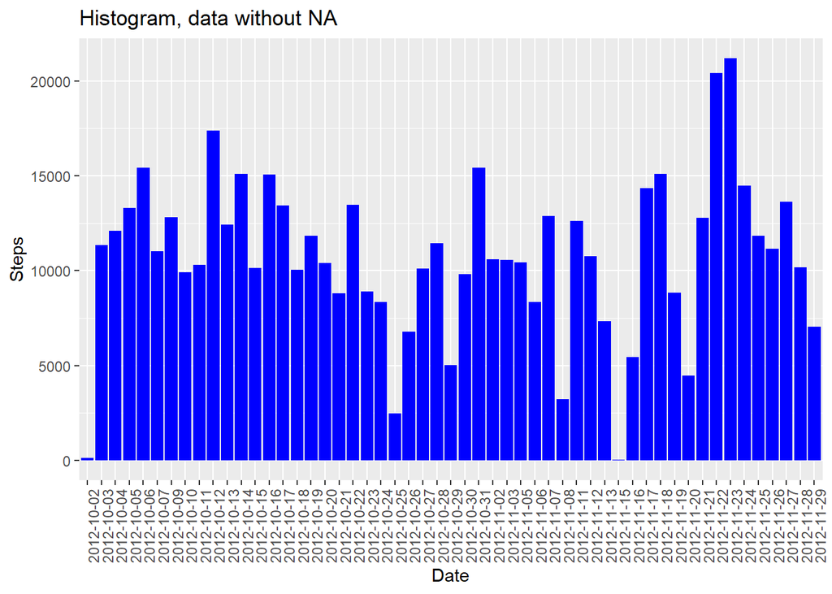

```r
# Histogram of the total number of steps taken each day

step_each_day <- data_na %>%
    group_by(month,day) %>%
    summarise(sum = sum(steps))
library(ggplot2)
hist <- ggplot(data_na, aes(x = date, y = steps)) + geom_bar(stat = "identity", fill = "blue") + labs(title = "Histogram, data without NA", x = "Date", y = "Steps") + theme(axis.text.x = element_text(angle = 90, hjust = 1))


hist
```

## Calculate the mean and median for each day

```r
# Mean and median number of steps taken each day

mean_median_per_day <- data_na %>%
    group_by(month,day)%>%
    summarise(mean = mean(steps),
              median = median(steps))
print(mean_median_per_day)
```

```
## # A tibble: 53 × 4
## # Groups:   month [2]
##    month day     mean median
##    <chr> <chr>  <dbl>  <dbl>
##  1 10    02     0.438      0
##  2 10    03    39.4        0
##  3 10    04    42.1        0
##  4 10    05    46.2        0
##  5 10    06    53.5        0
##  6 10    07    38.2        0
##  7 10    09    44.5        0
##  8 10    10    34.4        0
##  9 10    11    35.8        0
## 10 10    12    60.4        0
## # ℹ 43 more rows
```

## Use ggplot2 to graph the activity pattern and indicate the maximum value

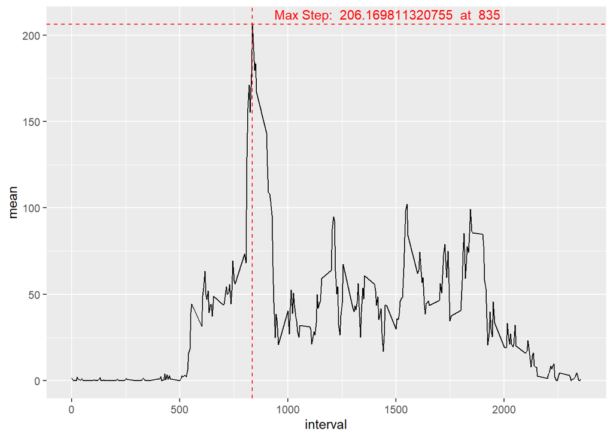

```r
# What is the average daily activity pattern?

step_each_interval <- data_na %>%
    group_by(interval)%>%
    summarise(mean = mean(steps))

max_interval <- step_each_interval %>%
    filter(mean == max(mean))

activity <- ggplot(step_each_interval, aes(x = interval, y = mean)) +
            geom_line() +
            geom_hline(yintercept = max_interval$mean, color = "red", linetype = "dashed") +
            annotate("text", x = max_interval$interval, y = max_interval$mean,
                     label = paste("Max Step: ", max_interval$mean, " at ", max_interval$interval), vjust = -0.5, hjust = -0.1, color = "red") +
            geom_vline(xintercept = max_interval$interval, color = "red", linetype = "dashed")



activity
```

## Imputing the missing values

```r
# Check all the columns

summary(is.na(data))
```

```
##    steps            date          interval         month
##  Mode :logical   Mode :logical   Mode :logical   Mode :logical
##  FALSE:15264     FALSE:17568     FALSE:17568     FALSE:17568
##  TRUE :2304
##     day
##  Mode :logical
##  FALSE:17568
##
```

## There are 2304 of missing values

## Strategy to fill the missing value:

- The values I plan to fill are based on the mean and sd of each interval. Therefore, I calculated the mean and sd from the data without NA to avoid bias
- Then merge the mean and sd data to my data frame “step_each_interval_fill” and set the value to be positive

```r
# Devise a strategy for filling the missing value

# The values I plan to fill are based on the mean and sd of each interval. Therefore, I calculated the mean and sd from the data without NA to avoid bias
step_each_interval_fill <- data_na %>%
    group_by(interval)%>%
    summarise(mean = mean(steps),
              sd = sd(steps))

# Then merge the mean and sd data to my data frame "step_each_interval_fill" and set the value to be positive
data_filled <- data%>%
    left_join(step_each_interval_fill, by = "interval")%>%
    mutate(steps = ifelse(is.na(steps), round(abs(rnorm(sum(is.na(steps)), mean = mean, sd = sd))), steps))
```

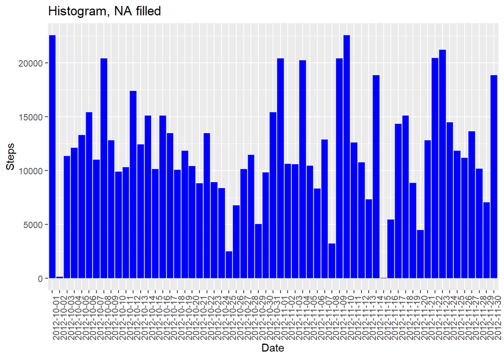

```r
# Make a histogram of the total number of steps taken each day and Calculate and report the mean and median total number of steps taken per day. Do these values differ from the estimates from the first part of the assignment? What is the impact of imputing missing data on the estimates of the total daily number of steps?


# histogram
library(ggplot2)
hist_nafill <- ggplot(data_filled, aes(x = date, y = steps)) + geom_bar(stat = "identity", fill = "blue") + labs(title = "Histogram, NA filled", x = "Date", y = "Steps") + theme(axis.text.x = element_text(angle = 90, hjust = 1))


hist_nafill
```

```r
# mean and median
mean_median_per_day <- data_filled %>%
    group_by(month,day)%>%
    summarise(mean = mean(steps),
              median = median(steps))
# print the result
print(mean_median_per_day)
```

```
## # A tibble: 61 × 4
## # Groups:   month [2]
##    month day     mean median
##    <chr> <chr>  <dbl>  <dbl>
##  1 10    01    78.3     37.5
##  2 10    02     0.438    0
##  3 10    03    39.4      0
##  4 10    04    42.1      0
##  5 10    05    46.2      0
##  6 10    06    53.5      0
##  7 10    07    38.2      0
##  8 10    08    70.9     39.5
##  9 10    09    44.5      0
## 10 10    10    34.4      0
## # ℹ 51 more rows
```

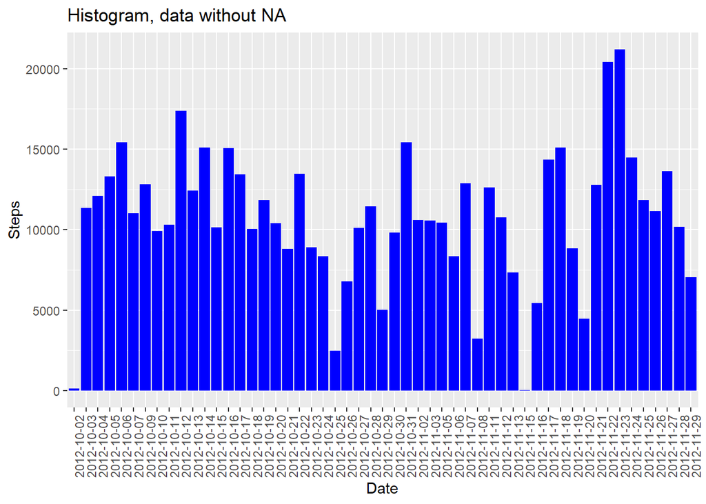

```r
# The output histogram for both data
hist
```

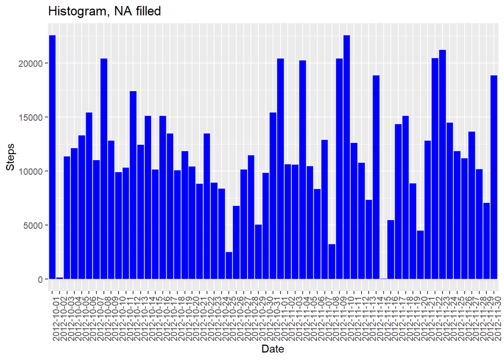

```r
hist_nafill
```

# To compare the data from “weekday” and “weekend” days,I extracted the data from both “weekday” and “weekend” days, and separate them into two data frame

```r
# Are there differences in activity patterns between weekdays and weekends?

# Create a new data frame
data_filled_wk <- data_filled

# Correct the date format as POSIXlt
data_filled_wk$date <- as.POSIXlt(data_filled_wk$date)

# Add a day_type column to indicate the "weekday" or "weekend"
data_filled_wk <- data_filled_wk%>%
    mutate(day_type = ifelse(weekdays(date) %in% c("Saturday", "Sunday"),"Weekend","Weekday"))

# Assign as factor for day_type
data_filled_wk$day_type <- as.factor(data_filled_wk$day_type)

# To be simple, subset the data frame by day_type
weekday <- filter(data_filled_wk, day_type == "Weekday")
weekend <- filter(data_filled_wk, day_type == "Weekend")
```

## For weekday

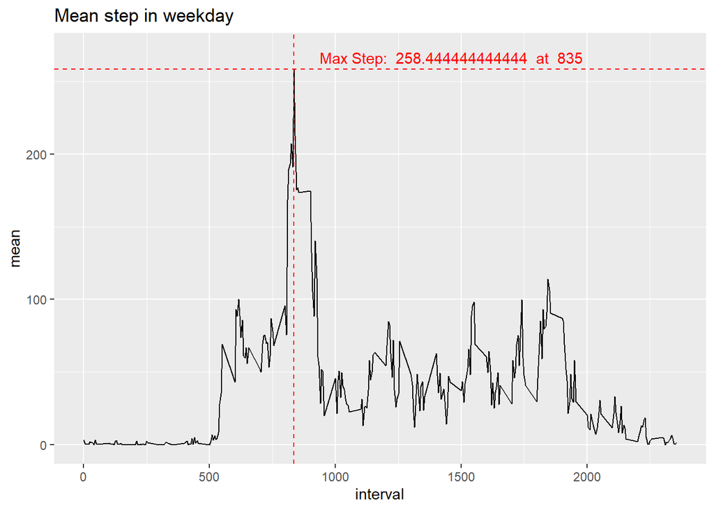

```r
# Calculate the data for weekday
weekday_sum <- weekday %>%
    group_by(interval)%>%
    summarise(mean = mean(steps))

weekday_max_interval <- weekday_sum %>%
    filter(mean == max(mean))



activity_weekday <- ggplot(weekday_sum, aes(x = interval, y = mean)) +
            geom_line() +
            geom_hline(yintercept = weekday_max_interval$mean, color = "red", linetype = "dashed") +
            annotate("text", x = weekday_max_interval$interval, y = weekday_max_interval$mean,
                     label = paste("Max Step: ", weekday_max_interval$mean, " at ", weekday_max_interval$interval),
                     vjust = -0.5, hjust = -0.1, color = "red") +
            geom_vline(xintercept = weekday_max_interval$interval, color = "red", linetype = "dashed") +
            labs(title ="Mean step in weekday") +
            ylim(0, 270)

activity_weekday
```

## For weekend

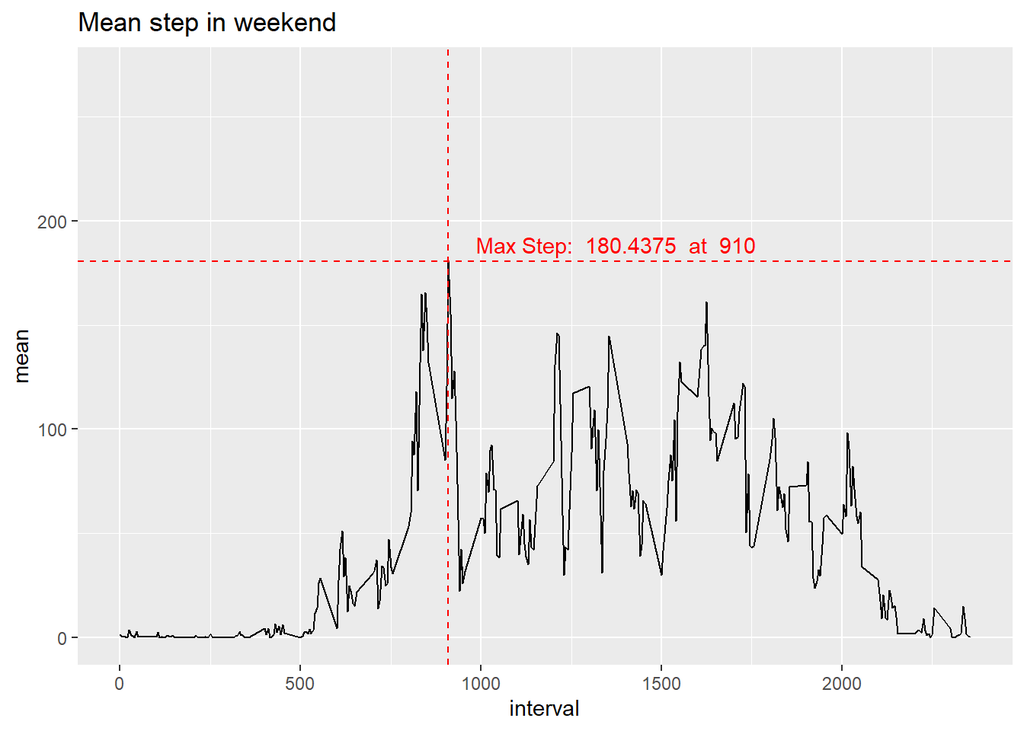

```r
# Calculate the data for weekend
weekend_sum <- weekend %>%
    group_by(interval)%>%
    summarise(mean = mean(steps))

weekend_max_interval <- weekend_sum %>%
    filter(mean == max(mean))



activity_weekend <- ggplot(weekend_sum, aes(x = interval, y = mean)) +
            geom_line() +
            geom_hline(yintercept = weekend_max_interval$mean, color = "red", linetype = "dashed") +
            annotate("text", x = weekend_max_interval$interval, y = weekend_max_interval$mean,
                     label = paste("Max Step: ", weekend_max_interval$mean, " at ", weekend_max_interval$interval),
                     vjust = -0.5, hjust = -0.1, color = "red") +
            geom_vline(xintercept = weekend_max_interval$interval, color = "red", linetype = "dashed") +
            labs(title ="Mean step in weekend") +
            ylim(0, 270)

activity_weekend
```

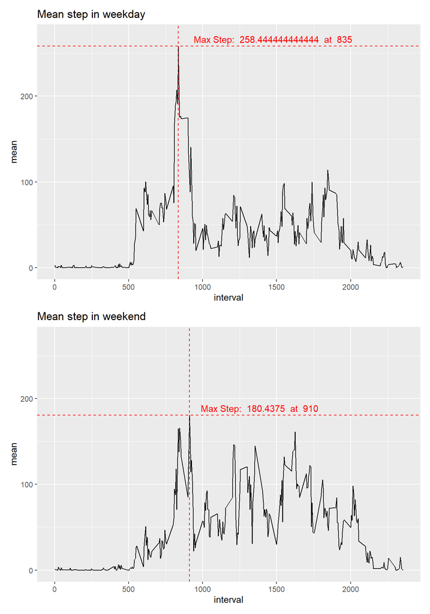

```r
library(patchwork)
combined_plot <- activity_weekday + activity_weekend

combined_plot <- combined_plot +
  plot_layout(ncol = 1)

print(combined_plot)
```